# Assignmetn 5 (prophet, auto-arima and external regressors)

Part 1. 10 pts - Exploratory Data Analysis

5 pts Merge the data sets together, should have 735 rows of data

```python
 pip install fbprophet
```

```python
import pandas as pd
import warnings
# Suppressing Warnings
warnings.filterwarnings('ignore')

co2_df = pd.read_csv('hw5_data_co2.csv')
temp_df = pd.read_csv('hw5_data_temp.csv')
co2_df.head(), temp_df.head()

# Inspecting the date columns
print(co2_df['ds'].head())
print(temp_df['ds'].head())
```

```
0    1958-03-15
1    1958-04-15
2    1958-05-15
3    1958-06-15
4    1958-07-15
Name: ds, dtype: object
0    1880-01-01
1    1880-02-01
2    1880-03-01
3    1880-04-01
4    1880-05-01
Name: ds, dtype: object
```

B. 5 pts Complete a quantitative and qualitative data exploration. Include a verbal summary of your EDA.

```
Missing dates in CO2 data: DatetimeIndex([], dtype='datetime64[ns]', freq='MS')
Missing dates in Temperature data: DatetimeIndex([], dtype='datetime64[ns]', freq=None)
        date      CO2  Temperature
0 1958-03-01  315.700        57.38
1 1958-04-01  317.450        57.29
2 1958-05-01  317.510        57.32
3 1958-06-01  316.685        57.02
4 1958-07-01  315.860        57.27
Number of rows in the merged dataset: 735
                                date         CO2  Temperature
count                            735  735.000000   735.000000
mean   1988-09-30 14:35:45.306122496  354.210673    57.603293
min              1958-03-01 00:00:00  313.200000    56.730000
25%              1973-06-16 00:00:00  328.785000    57.280000
50%              1988-10-01 00:00:00  351.340000    57.590000
75%              2004-01-16 12:00:00  376.515000    57.915000
max              2019-05-01 00:00:00  414.830000    58.840000
std                              NaN   27.922811     0.397159
```

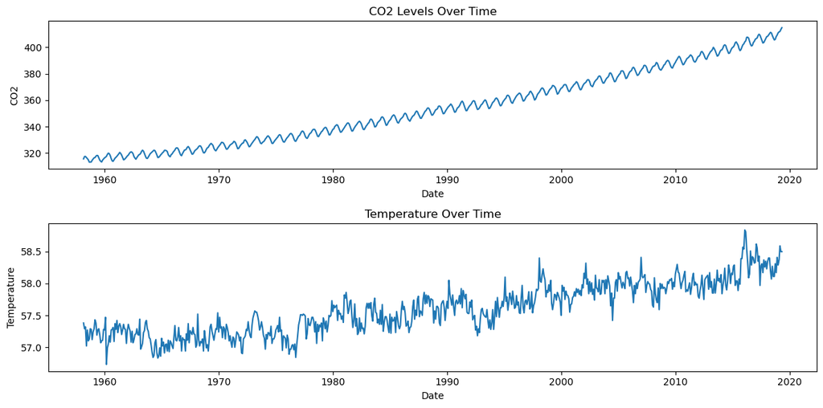

```python
import pandas as pd

# Renaming columns for clarity
co2_df.rename(columns={'ds': 'date', 'co2': 'CO2'}, inplace=True)
temp_df.rename(columns={'ds': 'date', 'temp': 'Temperature'}, inplace=True)

# Converting dates to datetime format
co2_df['date'] = pd.to_datetime(co2_df['date'])
temp_df['date'] = pd.to_datetime(temp_df['date'])

# Rounding CO2 dates to the start of the month
co2_df['date'] = co2_df['date'].dt.to_period('M').dt.to_timestamp()

# Checking for missing dates
complete_date_range = pd.date_range(start='1958-03-01', end='2019-05-01', freq='MS')
missing_dates_co2 = complete_date_range.difference(co2_df['date'])
missing_dates_temp = complete_date_range.difference(temp_df['date'])

print(f"Missing dates in CO2 data: {missing_dates_co2}")
print(f"Missing dates in Temperature data: {missing_dates_temp}")

# Filling missing dates in CO2 data
co2_full_df = pd.DataFrame({'date': complete_date_range}).merge(co2_df, on='date', how='left')
co2_full_df['CO2'] = co2_full_df['CO2'].fillna(method='ffill')

# Merging the datasets on the 'date' column
merged_df = pd.merge(co2_full_df, temp_df, on='date', how='inner')

# Displaying the first few rows of the merged dataset and check the number of rows
print(merged_df.head())
print(f"Number of rows in the merged dataset: {len(merged_df)}")

# Basic statistics
print(merged_df.describe())

# Time series plots
import matplotlib.pyplot as plt

plt.figure(figsize=(12, 6))

# CO2 plot
plt.subplot(2, 1, 1)
plt.plot(pd.to_datetime(merged_df['date']), merged_df['CO2'])
plt.title('CO2 Levels Over Time')
plt.xlabel('Date')
plt.ylabel('CO2')

# Temperature plot
plt.subplot(2, 1, 2)
plt.plot(pd.to_datetime(merged_df['date']), merged_df['Temperature'])
plt.title('Temperature Over Time')
plt.xlabel('Date')
plt.ylabel('Temperature')

plt.tight_layout()
plt.show()
```

Part 2. 35 pts – ARIMA with external regressors

A. 7 pts Split Temp into train test. Determine the transformation, seasonal differencing & non seasonal differencing orders if required. Include the following: plot of differenced data, ADF results, kpss results, ACF/PACF plots.

```
Training set size: 588
Test set size: 147
```

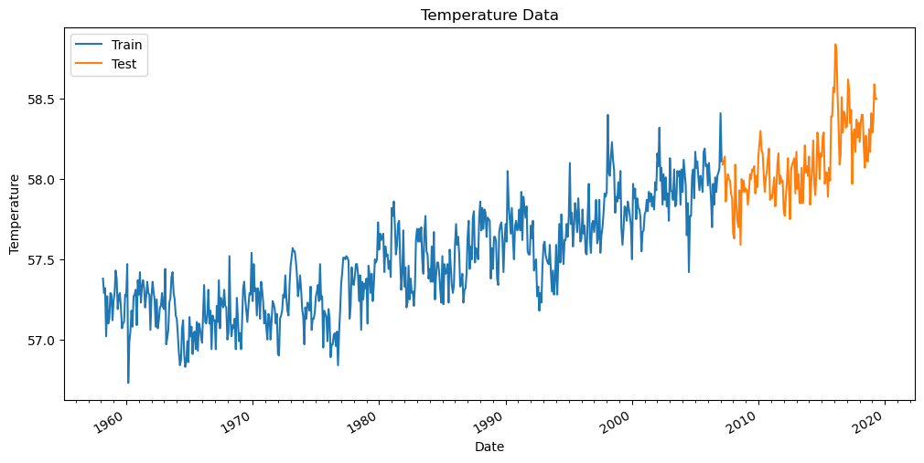

```python
import pandas as pd
import matplotlib.pyplot as plt
import matplotlib.dates as mdates
# Converting the 'date' column to datetime if not already done
merged_df['date'] = pd.to_datetime(merged_df['date'])
merged_df.set_index('date', inplace=True)

# Splitting the data
train_size = int(len(merged_df) * 0.8)
train, test = merged_df[:train_size], merged_df[train_size:]

# Displaying the split sizes
print(f"Training set size: {len(train)}")
print(f"Test set size: {len(test)}")

# Plotting the data
plt.figure(figsize=(12, 6))
plt.plot(train.index, train['Temperature'], label='Train')
plt.plot(test.index, test['Temperature'], label='Test')
plt.title('Temperature Data')
plt.xlabel('Date')
plt.ylabel('Temperature')
plt.legend()

# Formating the x-axis to show dates with a 10-year interval
plt.gca().xaxis.set_major_locator(mdates.YearLocator(10))  # Set major ticks to every 10 years
plt.gca().xaxis.set_minor_locator(mdates.YearLocator(1))  # Set minor ticks to every year
plt.gca().xaxis.set_major_formatter(mdates.DateFormatter('%Y'))  # Format major ticks as 'Year'
plt.gcf().autofmt_xdate()  # Rotate and align the x labels
plt.show()
```

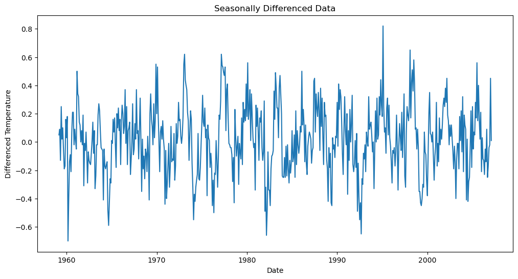

```python
# Seasonal differencing
seasonal_diff = train['Temperature'].diff(12).dropna()

# Plotting the seasonal differenced data
plt.figure(figsize=(12, 6))
plt.plot(seasonal_diff)
plt.title('Seasonally Differenced Data')
plt.xlabel('Date')
plt.ylabel('Differenced Temperature')
plt.show()
```

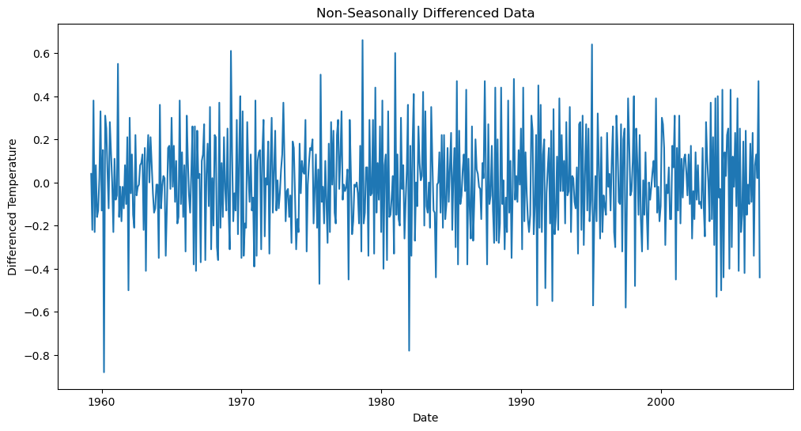

```python
# Non-seasonal differencing
non_seasonal_diff = seasonal_diff.diff().dropna()

# Plotting the non-seasonally differenced data
plt.figure(figsize=(12, 6))
plt.plot(non_seasonal_diff)
plt.title('Non-Seasonally Differenced Data')
plt.xlabel('Date')
plt.ylabel('Differenced Temperature')
plt.show()
```

```python
import pandas as pd
import numpy as np
import matplotlib.pyplot as plt
import seaborn as sns
import matplotlib.dates as mdates
from statsmodels.tsa.stattools import adfuller, kpss
from statsmodels.graphics.tsaplots import plot_acf, plot_pacf
from statsmodels.tsa.statespace.sarimax import SARIMAX
from statsmodels.stats.diagnostic import acorr_ljungbox
from sklearn.metrics import mean_absolute_error, mean_squared_error

# Performing ADF test
adf_result = adfuller(non_seasonal_diff)
print(f'ADF Statistic: {adf_result[0]}')
print(f'p-value: {adf_result[1]}')
print('Critical Values:')
for key, value in adf_result[4].items():
    print(f'   {key}: {value}')
```

```
ADF Statistic: -11.056635655546255
p-value: 4.926105350473702e-20
Critical Values:
   1%: -3.442102384299813
   5%: -2.8667242618524233
   10%: -2.569531046591633
```

```python
# Perform KPSS test
kpss_result = kpss(non_seasonal_diff, regression='c')
print(f'KPSS Statistic: {kpss_result[0]}')
print(f'p-value: {kpss_result[1]}')
print('Critical Values:')
for key, value in kpss_result[3].items():
    print(f'   {key}: {value}')
```

```
KPSS Statistic: 0.044777942793231267
p-value: 0.1
Critical Values:
   10%: 0.347
   5%: 0.463
   2.5%: 0.574
   1%: 0.739
```

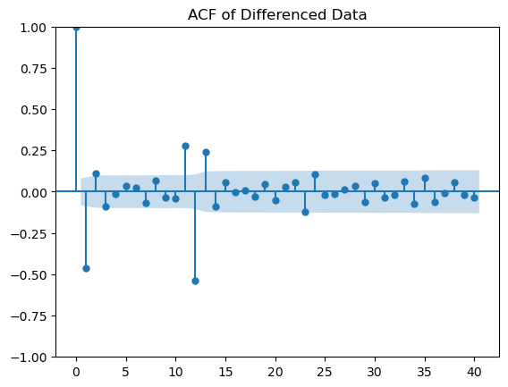

```python
# Plotting ACF
plt.figure(figsize=(12, 6))
plot_acf(non_seasonal_diff, lags=40)
plt.title('ACF of Differenced Data')
plt.show()
```

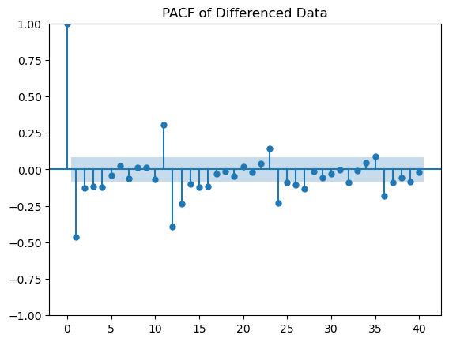

```python
# Plotting PACF
plt.figure(figsize=(12, 6))
plot_pacf(non_seasonal_diff, lags=40)
plt.title('PACF of Differenced Data')
plt.show()
```

7 pts Fit a SARIMA or ARIMA model based on your examinations. Examine the residuals. Include the following: plot, histogram, ACF, Ljung Box results. Check if auto arima gives you a different order. If this is a better model, examine the residuals of this model.

```python
#Fitting ARIMA model
arima_model = SARIMAX(train['Temperature'], order=(1, 1, 1))
arima_result = arima_model.fit(disp=False)
print(arima_result.summary())
```

```
                               SARIMAX Results
==============================================================================
Dep. Variable:            Temperature   No. Observations:                  588
Model:               SARIMAX(1, 1, 1)   Log Likelihood                 309.613
Date:                Sun, 28 Jul 2024   AIC                           -613.227
Time:                        20:15:31   BIC                           -600.102
Sample:                    03-01-1958   HQIC                          -608.113
                         - 02-01-2007
Covariance Type:                  opg
==============================================================================
                 coef    std err          z      P>|z|      [0.025      0.975]
------------------------------------------------------------------------------
ar.L1          0.1693      0.070      2.401      0.016       0.031       0.307
ma.L1         -0.7120      0.051    -14.012      0.000      -0.812      -0.612
sigma2         0.0204      0.001     19.493      0.000       0.018       0.022
===================================================================================
Ljung-Box (L1) (Q):                   0.18   Jarque-Bera (JB):                 9.81
Prob(Q):                              0.67   Prob(JB):                         0.01
Heteroskedasticity (H):               1.22   Skew:                            -0.03
Prob(H) (two-sided):                  0.16   Kurtosis:                         3.63
===================================================================================

Warnings:
[1] Covariance matrix calculated using the outer product of gradients (complex-step).
```

```python
import pmdarima as pm


auto_arima_model = pm.auto_arima(train['Temperature'], seasonal=False, m=12,
                                 d=1, D=1, trace=True, error_action='ignore', suppress_warnings=True,
                                 stepwise=True)

# Print model summary
print(auto_arima_model.summary())

# Make predictions
auto_arima_predictions = auto_arima_model.predict(n_periods=len(test))
test['Predicted_Temperature_Auto_ARIMA'] = auto_arima_predictions

# Calculate residuals
auto_residuals = test['Temperature'] - test['Predicted_Temperature_Auto_ARIMA']
```

```
Performing stepwise search to minimize aic
 ARIMA(2,1,2)(0,0,0)[0] intercept   : AIC=-630.209, Time=1.42 sec
 ARIMA(0,1,0)(0,0,0)[0] intercept   : AIC=-460.057, Time=0.23 sec
 ARIMA(1,1,0)(0,0,0)[0] intercept   : AIC=-578.528, Time=0.28 sec
 ARIMA(0,1,1)(0,0,0)[0] intercept   : AIC=-610.398, Time=0.28 sec
 ARIMA(0,1,0)(0,0,0)[0]             : AIC=-462.023, Time=0.25 sec
 ARIMA(1,1,2)(0,0,0)[0] intercept   : AIC=-608.995, Time=1.07 sec
 ARIMA(2,1,1)(0,0,0)[0] intercept   : AIC=-633.154, Time=1.42 sec
 ARIMA(1,1,1)(0,0,0)[0] intercept   : AIC=-611.725, Time=0.75 sec
 ARIMA(2,1,0)(0,0,0)[0] intercept   : AIC=-585.811, Time=0.31 sec
 ARIMA(3,1,1)(0,0,0)[0] intercept   : AIC=-631.154, Time=1.46 sec
 ARIMA(3,1,0)(0,0,0)[0] intercept   : AIC=-605.169, Time=0.67 sec
 ARIMA(3,1,2)(0,0,0)[0] intercept   : AIC=-630.352, Time=2.44 sec
 ARIMA(2,1,1)(0,0,0)[0]             : AIC=-630.756, Time=0.49 sec

Best model:  ARIMA(2,1,1)(0,0,0)[0] intercept
Total fit time: 11.083 seconds
                               SARIMAX Results
==============================================================================
Dep. Variable:                      y   No. Observations:                  588
Model:               SARIMAX(2, 1, 1)   Log Likelihood                 321.577
Date:                Sun, 28 Jul 2024   AIC                           -633.154
Time:                        17:57:07   BIC                           -611.279
Sample:                    03-01-1958   HQIC                          -624.630
                         - 02-01-2007
Covariance Type:                  opg
==============================================================================
                 coef    std err          z      P>|z|      [0.025      0.975]
------------------------------------------------------------------------------
intercept      0.0005      0.000      2.760      0.006       0.000       0.001
ar.L1          0.3967      0.044      9.113      0.000       0.311       0.482
ar.L2          0.2592      0.046      5.692      0.000       0.170       0.348
ma.L1         -0.9731      0.012    -79.318      0.000      -0.997      -0.949
sigma2         0.0195      0.001     19.640      0.000       0.018       0.021
===================================================================================
Ljung-Box (L1) (Q):                   0.00   Jarque-Bera (JB):                12.28
Prob(Q):                              0.95   Prob(JB):                         0.00
Heteroskedasticity (H):               1.18   Skew:                             0.00
Prob(H) (two-sided):                  0.26   Kurtosis:                         3.71
===================================================================================

Warnings:
[1] Covariance matrix calculated using the outer product of gradients (complex-step).
```

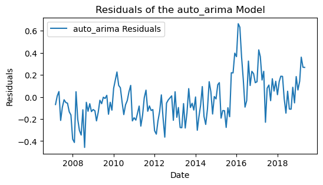

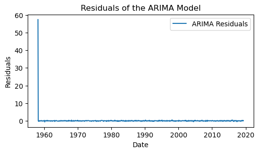

```python
# Plot residuals for auto_arima
plt.figure(figsize=(6, 3))
plt.plot(auto_residuals, label='auto_arima Residuals')
plt.title('Residuals of the auto_arima Model')
plt.xlabel('Date')
plt.ylabel('Residuals')
plt.legend()
plt.show()

# Plot residuals for SARIMA
plt.figure(figsize=(6, 3))
plt.plot(arima_residuals, label='ARIMA Residuals')
plt.title('Residuals of the ARIMA Model')
plt.xlabel('Date')
plt.ylabel('Residuals')
plt.legend()
plt.show()
```

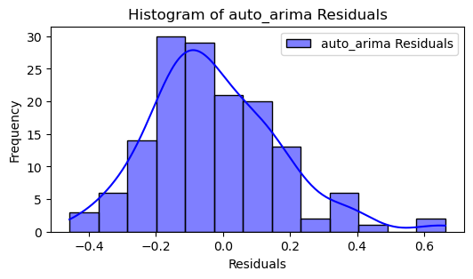

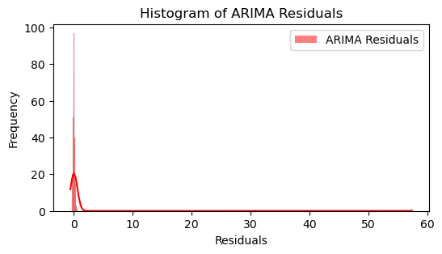

```python
import pandas as pd
import pmdarima as pm
import matplotlib.pyplot as plt
import seaborn as sns

# Histogram of residuals for auto_arima
plt.figure(figsize=(6, 3))
sns.histplot(auto_residuals, kde=True, label='auto_arima Residuals', color='blue')
plt.title('Histogram of auto_arima Residuals')
plt.xlabel('Residuals')
plt.ylabel('Frequency')
plt.legend()
plt.show()

# Histogram of residuals for ARIMA
plt.figure(figsize=(6, 3))
sns.histplot(arima_residuals, kde=True, label='ARIMA Residuals', color='red')
plt.title('Histogram of ARIMA Residuals')
plt.xlabel('Residuals')
plt.ylabel('Frequency')
plt.legend()
plt.show()
```

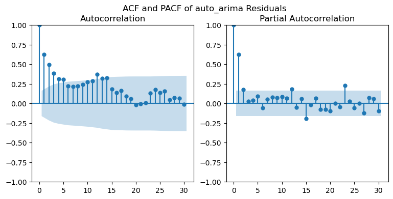

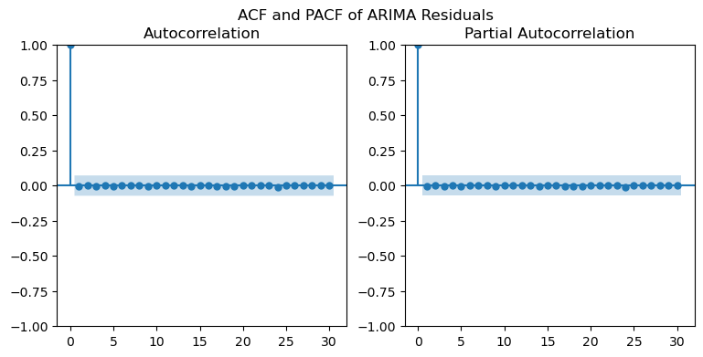

```python
# ACF and PACF plots for auto_arima residuals
fig, ax = plt.subplots(1, 2, figsize=(9, 4))
plot_acf(auto_residuals, ax=ax[0], lags=30)
plot_pacf(auto_residuals, ax=ax[1], lags=30)
plt.suptitle('ACF and PACF of auto_arima Residuals')
plt.show()

# ACF and PACF plots for SARIMA residuals
fig, ax = plt.subplots(1, 2, figsize=(9, 4))
plot_acf(arima_residuals, ax=ax[0], lags=30)
plot_pacf(arima_residuals, ax=ax[1], lags=30)
plt.suptitle('ACF and PACF of ARIMA Residuals')
plt.show()
```

```python
from statsmodels.stats.diagnostic import acorr_ljungbox
# Ljung-Box test for auto_arima residuals
lb_test_auto = acorr_ljungbox(auto_residuals, lags=[10], return_df=True)
print("Ljung-Box test results for auto_arima:")
print(lb_test_auto)

# Ljung-Box test for ARIMA residuals
lb_test_arima = acorr_ljungbox(arima_residuals, lags=[10], return_df=True)
print("Ljung-Box test results for ARIMA:")
print(lb_test_arima)
```

```
Ljung-Box test results for auto_arima:
       lb_stat     lb_pvalue
10  191.978261  7.575515e-36
Ljung-Box test results for ARIMA:
     lb_stat  lb_pvalue
10  0.043945        1.0
```

C. 7pts Using your best model, predict the test set. Include the following: MAE, MSE, MAPE, sMAPE, MASE. Can use prebuilt functions or calculate by hand.

```python
import matplotlib.pyplot as plt
import seaborn as sns
from statsmodels.stats.diagnostic import acorr_ljungbox
import numpy as np
import pandas as pd
import pmdarima as pm
from sklearn.metrics import mean_absolute_error, mean_squared_error

# Fitting ARIMA model using auto_arima
arima_model = pm.auto_arima(train['Temperature'], seasonal=False, trace=True, error_action='ignore', suppress_warnings=True)

# Printing model summary
print(arima_model.summary())

# Using the ARIMA model for prediction
arima_predictions = arima_model.predict(n_periods=len(test))
test['Predicted_Temperature_ARIMA'] = arima_predictions

# Calculating naive forecast (last observed value in the training set)
naive_forecast = train['Temperature'].iloc[-1]
test['Naive_Forecast'] = naive_forecast

# Performance metrics
mae_arima = mean_absolute_error(test['Temperature'], test['Predicted_Temperature_ARIMA'])
mse_arima = mean_squared_error(test['Temperature'], test['Predicted_Temperature_ARIMA'])
mape_arima = np.mean(np.abs((test['Temperature'] - test['Predicted_Temperature_ARIMA']) / test['Temperature'])) * 100
smape_arima = 100 / len(test) * np.sum(2 * np.abs(test['Predicted_Temperature_ARIMA'] - test['Temperature']) / (np.abs(test['Temperature']) + np.abs(test['Predicted_Temperature_ARIMA'])))

# Printing the performance metrics for ARIMA
print(f'MAE (ARIMA): {mae_arima}')
print(f'MSE (ARIMA): {mse_arima}')
print(f'MAPE (ARIMA): {mape_arima}')
print(f'sMAPE (ARIMA): {smape_arima}')
```

```
Performing stepwise search to minimize aic
 ARIMA(2,1,2)(0,0,0)[0] intercept   : AIC=-630.209, Time=1.45 sec
 ARIMA(0,1,0)(0,0,0)[0] intercept   : AIC=-460.057, Time=0.26 sec
 ARIMA(1,1,0)(0,0,0)[0] intercept   : AIC=-578.528, Time=0.31 sec
 ARIMA(0,1,1)(0,0,0)[0] intercept   : AIC=-610.398, Time=0.35 sec
 ARIMA(0,1,0)(0,0,0)[0]             : AIC=-462.023, Time=0.25 sec
 ARIMA(1,1,2)(0,0,0)[0] intercept   : AIC=-608.995, Time=1.01 sec
 ARIMA(2,1,1)(0,0,0)[0] intercept   : AIC=-633.154, Time=1.18 sec
 ARIMA(1,1,1)(0,0,0)[0] intercept   : AIC=-611.725, Time=0.71 sec
 ARIMA(2,1,0)(0,0,0)[0] intercept   : AIC=-585.811, Time=0.29 sec
 ARIMA(3,1,1)(0,0,0)[0] intercept   : AIC=-631.154, Time=1.58 sec
 ARIMA(3,1,0)(0,0,0)[0] intercept   : AIC=-605.169, Time=0.68 sec
 ARIMA(3,1,2)(0,0,0)[0] intercept   : AIC=-630.352, Time=2.39 sec
 ARIMA(2,1,1)(0,0,0)[0]             : AIC=-630.756, Time=0.40 sec

Best model:  ARIMA(2,1,1)(0,0,0)[0] intercept
Total fit time: 10.873 seconds
                               SARIMAX Results
==============================================================================
Dep. Variable:                      y   No. Observations:                  588
Model:               SARIMAX(2, 1, 1)   Log Likelihood                 321.577
Date:                Sun, 28 Jul 2024   AIC                           -633.154
Time:                        18:04:52   BIC                           -611.279
Sample:                    03-01-1958   HQIC                          -624.630
                         - 02-01-2007
Covariance Type:                  opg
==============================================================================
                 coef    std err          z      P>|z|      [0.025      0.975]
------------------------------------------------------------------------------
intercept      0.0005      0.000      2.760      0.006       0.000       0.001
ar.L1          0.3967      0.044      9.113      0.000       0.311       0.482
ar.L2          0.2592      0.046      5.692      0.000       0.170       0.348
ma.L1         -0.9731      0.012    -79.318      0.000      -0.997      -0.949
sigma2         0.0195      0.001     19.640      0.000       0.018       0.021
===================================================================================
Ljung-Box (L1) (Q):                   0.00   Jarque-Bera (JB):                12.28
Prob(Q):                              0.95   Prob(JB):                         0.00
Heteroskedasticity (H):               1.18   Skew:                             0.00
Prob(H) (two-sided):                  0.26   Kurtosis:                         3.71
===================================================================================

Warnings:
[1] Covariance matrix calculated using the outer product of gradients (complex-step).
MAE (ARIMA): 0.15309843256094421
MSE (ARIMA): 0.03751745173435893
MAPE (ARIMA): 0.26337227709929983
sMAPE (ARIMA): 0.26335725534080195
```

D. pts Refit your best model by adding co2 as an external regressor. Examine the residuals of this model

```python
import pmdarima as pm
import pandas as pd
import matplotlib.pyplot as plt
import seaborn as sns
from statsmodels.graphics.tsaplots import plot_acf, plot_pacf
from statsmodels.stats.diagnostic import acorr_ljungbox
from sklearn.metrics import mean_absolute_error, mean_squared_error
import numpy as np

# exogenous variables
exog = merged_df[['CO2']]

# Splitting data into train and test sets
train_size = int(len(merged_df) * 0.8)
train, test = merged_df[:train_size], merged_df[train_size:]
train_exog, test_exog = exog[:train_size], exog[train_size:]

# Fitting ARIMA with external regressor
model = pm.auto_arima(train['Temperature'], exogenous=train_exog, seasonal=False, trace=True, error_action='ignore', suppress_warnings=True)

# Printing model summary
print(model.summary())

# Making predictions with external regressor
arima_predictions_exog = model.predict(n_periods=len(test), exogenous=test_exog)
test['Predicted_Temperature_ARIMA_Exog'] = arima_predictions_exog

# Calculating residuals
residuals_exog = test['Temperature'] - test['Predicted_Temperature_ARIMA_Exog']
```

```
Performing stepwise search to minimize aic
 ARIMA(2,1,2)(0,0,0)[0] intercept   : AIC=-630.209, Time=1.39 sec
 ARIMA(0,1,0)(0,0,0)[0] intercept   : AIC=-460.057, Time=0.25 sec
 ARIMA(1,1,0)(0,0,0)[0] intercept   : AIC=-578.528, Time=0.28 sec
 ARIMA(0,1,1)(0,0,0)[0] intercept   : AIC=-610.398, Time=0.31 sec
 ARIMA(0,1,0)(0,0,0)[0]             : AIC=-462.023, Time=0.20 sec
 ARIMA(1,1,2)(0,0,0)[0] intercept   : AIC=-608.995, Time=0.94 sec
 ARIMA(2,1,1)(0,0,0)[0] intercept   : AIC=-633.154, Time=1.32 sec
 ARIMA(1,1,1)(0,0,0)[0] intercept   : AIC=-611.725, Time=0.63 sec
 ARIMA(2,1,0)(0,0,0)[0] intercept   : AIC=-585.811, Time=0.37 sec
 ARIMA(3,1,1)(0,0,0)[0] intercept   : AIC=-631.154, Time=1.63 sec
 ARIMA(3,1,0)(0,0,0)[0] intercept   : AIC=-605.169, Time=0.64 sec
 ARIMA(3,1,2)(0,0,0)[0] intercept   : AIC=-630.352, Time=2.30 sec
 ARIMA(2,1,1)(0,0,0)[0]             : AIC=-630.756, Time=0.43 sec

Best model:  ARIMA(2,1,1)(0,0,0)[0] intercept
Total fit time: 10.702 seconds
                               SARIMAX Results
==============================================================================
Dep. Variable:                      y   No. Observations:                  588
Model:               SARIMAX(2, 1, 1)   Log Likelihood                 321.577
Date:                Sun, 28 Jul 2024   AIC                           -633.154
Time:                        18:07:50   BIC                           -611.279
Sample:                    03-01-1958   HQIC                          -624.630
                         - 02-01-2007
Covariance Type:                  opg
==============================================================================
                 coef    std err          z      P>|z|      [0.025      0.975]
------------------------------------------------------------------------------
intercept      0.0005      0.000      2.760      0.006       0.000       0.001
ar.L1          0.3967      0.044      9.113      0.000       0.311       0.482
ar.L2          0.2592      0.046      5.692      0.000       0.170       0.348
ma.L1         -0.9731      0.012    -79.318      0.000      -0.997      -0.949
sigma2         0.0195      0.001     19.640      0.000       0.018       0.021
===================================================================================
Ljung-Box (L1) (Q):                   0.00   Jarque-Bera (JB):                12.28
Prob(Q):                              0.95   Prob(JB):                         0.00
Heteroskedasticity (H):               1.18   Skew:                             0.00
Prob(H) (two-sided):                  0.26   Kurtosis:                         3.71
===================================================================================

Warnings:
[1] Covariance matrix calculated using the outer product of gradients (complex-step).
```

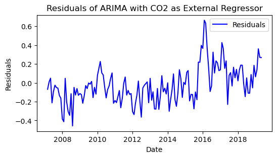

```python
# Plotting residuals
plt.figure(figsize=(6, 3))
plt.plot(residuals_exog, label='Residuals', color='blue')
plt.title('Residuals of ARIMA with CO2 as External Regressor')
plt.xlabel('Date')
plt.ylabel('Residuals')
plt.legend()
plt.show()
```

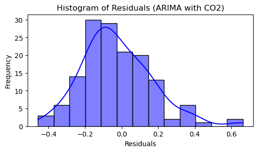

```python
# Ploting histogram of residuals
plt.figure(figsize=(6, 3))
sns.histplot(residuals_exog, kde=True, color='blue')
plt.title('Histogram of Residuals (ARIMA with CO2)')
plt.xlabel('Residuals')
plt.ylabel('Frequency')
plt.show()
```

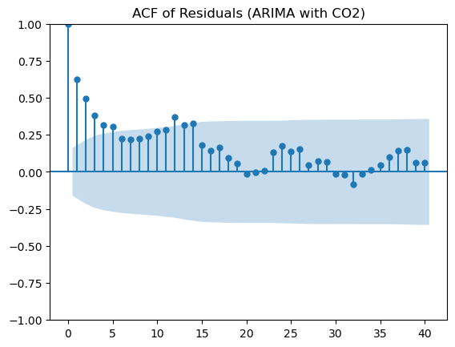

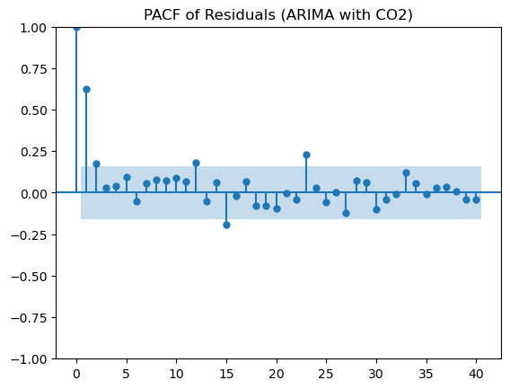

```python
# Ploting ACF of residuals
plt.figure(figsize=(6, 3))
plot_acf(residuals_exog, lags=40)
plt.title('ACF of Residuals (ARIMA with CO2)')
plt.show()

# Plotting PACF of residuals
plt.figure(figsize=(6, 3))
plot_pacf(residuals_exog, lags=40)
plt.title('PACF of Residuals (ARIMA with CO2)')
plt.show()
```

```python
# Performing Ljung-Box test on residuals
lb_test_results = acorr_ljungbox(residuals_exog, lags=[10], return_df=True)
print(lb_test_results)
```

```
       lb_stat     lb_pvalue
10  191.978261  7.575515e-36
```

E. 7 pts Predict the test set. Include the following: MAE, MSE, MAPE, sMAPE, MASE. Can use prebuilt functions or calculate by hand.

```python
import pandas as pd
import numpy as np
from statsmodels.tsa.statespace.sarimax import SARIMAX
from sklearn.metrics import mean_absolute_error, mean_squared_error

# Splitting data into train and test sets
train_size = int(len(merged_df) * 0.8)
train, test = merged_df[:train_size], merged_df[train_size:]
exog_train = train[['CO2']]
exog_test = test[['CO2']]

# Fitting ARIMA with external regressor using SARIMAX
model_exog = SARIMAX(train['Temperature'], exog=exog_train, order=(1, 1, 1), seasonal_order=(1, 1, 1, 12))
model_exog_fit = model_exog.fit(disp=False)
print(model_exog_fit.summary())

# Predictting the test set with the model with external regressor
test_predictions_exog = model_exog_fit.get_forecast(steps=len(test), exog=exog_test).predicted_mean
test['Predicted_Temperature_Exog'] = test_predictions_exog

# Performance metrics with external regressor
mae_exog = mean_absolute_error(test['Temperature'], test['Predicted_Temperature_Exog'])
mse_exog = mean_squared_error(test['Temperature'], test['Predicted_Temperature_Exog'])
mape_exog = np.mean(np.abs((test['Temperature'] - test['Predicted_Temperature_Exog']) / test['Temperature'])) * 100
smape_exog = 100 / len(test) * np.sum(2 * np.abs(test['Predicted_Temperature_Exog'] - test['Temperature']) / (np.abs(test['Temperature']) + np.abs(test['Predicted_Temperature_Exog'])))

# Calculating MASE with external regressor
naive_forecast_errors = test['Temperature'].diff().dropna()
mae_naive = np.mean(np.abs(naive_forecast_errors))
mase_exog = mae_exog / mae_naive

# Printing performance metrics
print(f'MAE with CO2 Regressor: {mae_exog}')
print(f'MSE with CO2 Regressor: {mse_exog}')
print(f'MAPE with CO2 Regressor: {mape_exog}')
print(f'sMAPE with CO2 Regressor: {smape_exog}')
print(f'MASE with CO2 Regressor: {mase_exog}')
```

```
                                     SARIMAX Results
==========================================================================================
Dep. Variable:                        Temperature   No. Observations:                  588
Model:             SARIMAX(1, 1, 1)x(1, 1, 1, 12)   Log Likelihood                 286.855
Date:                            Sun, 28 Jul 2024   AIC                           -561.710
Time:                                    18:17:17   BIC                           -535.584
Sample:                                03-01-1958   HQIC                          -551.520
                                     - 02-01-2007
Covariance Type:                              opg
==============================================================================
                 coef    std err          z      P>|z|      [0.025      0.975]
------------------------------------------------------------------------------
CO2            0.0036      0.020      0.186      0.852      -0.035       0.042
ar.L1          0.0967      0.072      1.348      0.178      -0.044       0.237
ma.L1         -0.6763      0.054    -12.610      0.000      -0.781      -0.571
ar.S.L12      -0.0573      0.045     -1.273      0.203      -0.145       0.031
ma.S.L12      -0.9678      0.034    -28.550      0.000      -1.034      -0.901
sigma2         0.0203      0.001     18.016      0.000       0.018       0.023
===================================================================================
Ljung-Box (L1) (Q):                   0.05   Jarque-Bera (JB):                 5.00
Prob(Q):                              0.82   Prob(JB):                         0.08
Heteroskedasticity (H):               1.12   Skew:                            -0.03
Prob(H) (two-sided):                  0.43   Kurtosis:                         3.45
===================================================================================

Warnings:
[1] Covariance matrix calculated using the outer product of gradients (complex-step).
MAE with CO2 Regressor: 0.19393024184315014
MSE with CO2 Regressor: 0.05568357361912254
MAPE with CO2 Regressor: 0.33426998890414517
sMAPE with CO2 Regressor: 0.33358385317893546
MASE with CO2 Regressor: 1.4909855349710324
```

Part 3. 35 pts – Prophet with additional regressors

10 pts Using the same train test split as part 2, fit a prophet model to your NON-differenced training set. Examine the residuals. Using the predicted values and y train, calculate the following: MAE, MSE, MAPE, sMAPE, MASE. Can use prebuilt functions or calculate by hand.

```python
!pip install prophet
```

```
19:31:49 - cmdstanpy - INFO - Chain [1] start processing
19:31:49 - cmdstanpy - INFO - Chain [1] done processing
```

```
Training MAE: 0.11674180688939151
Training MSE: 0.02172088831937009
Training MAPE: 0.203074898772251
Training sMAPE: 0.20308192435316375
Training MASE: 0.9060880688096363
Test MAE: 0.15613727124768717
Test MSE: 0.03776940370412963
Test MAPE: 0.2688299959568433
Test sMAPE: 0.2686138633019003
Test MASE: 1.2004234650954353
```

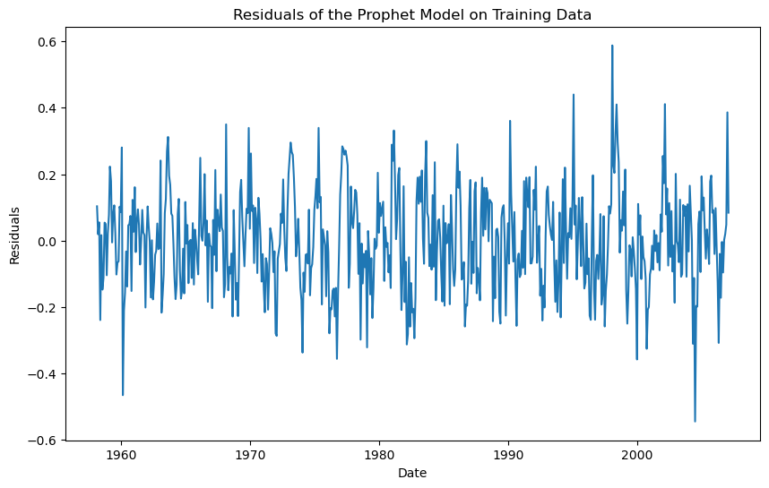

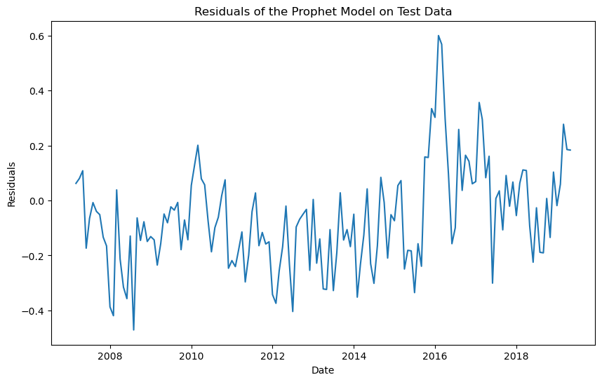

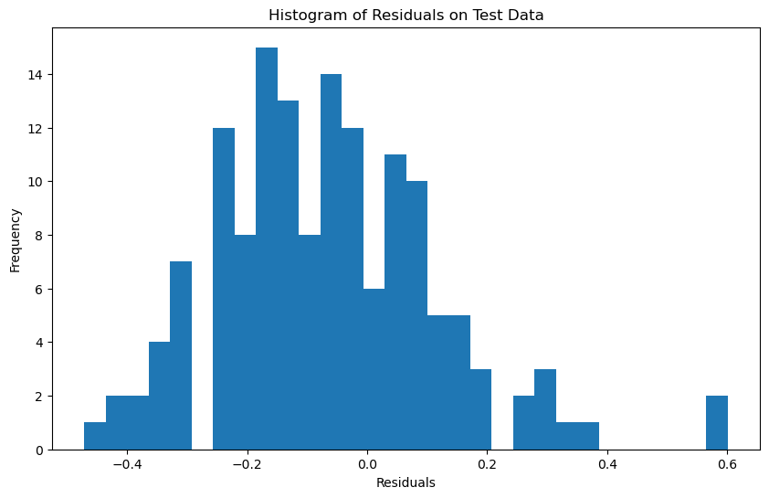

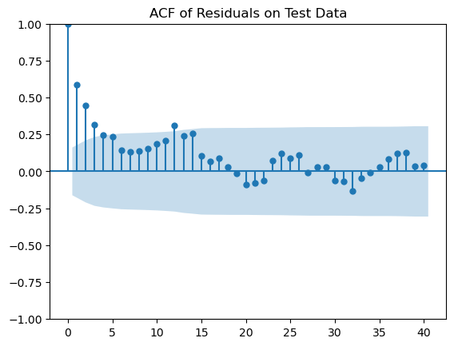

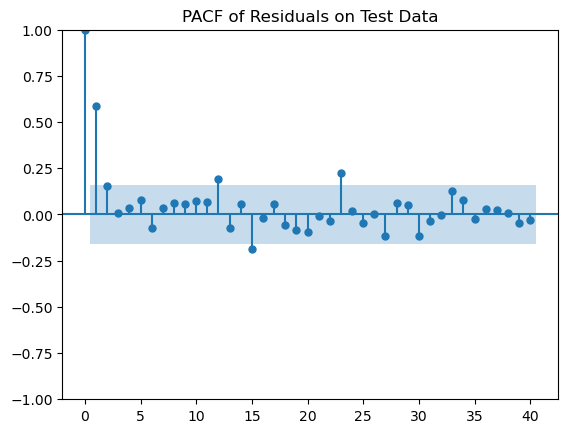

```
       lb_stat     lb_pvalue
10  132.765661  1.273133e-23
```

```python
import pandas as pd
import numpy as np
from prophet import Prophet
from sklearn.metrics import mean_absolute_error, mean_squared_error
import matplotlib.pyplot as plt
import seaborn as sns
from statsmodels.graphics.tsaplots import plot_acf, plot_pacf
from statsmodels.stats.diagnostic import acorr_ljungbox

# Ensuring train and test sets have necessary columns for Prophet
train['ds'] = train.index
train['y'] = train['Temperature']

test['ds'] = test.index
test['y'] = test['Temperature']

# Fitting Prophet model
model = Prophet(yearly_seasonality=False, weekly_seasonality=False, daily_seasonality=False, changepoint_prior_scale=0.5)
model.fit(train[['ds', 'y']])

# Create a dataframe for future predictions
future_data = model.make_future_dataframe(periods=len(test), freq='M')
future_data['ds'] = future_data['ds'] + pd.offsets.MonthBegin(0)

# Making predictions
forecast_data = model.predict(future_data)

# Extracting the forecast for the training period
train_forecast = forecast_data.set_index('ds').loc[train.index]

# Extracting the forecast for the test period
test_forecast = forecast_data.set_index('ds').loc[test.index]

# Calculating residuals for the training set
train_residuals = train['y'] - train_forecast['yhat']

# Calculating residuals for the test set
test_residuals = test['y'] - test_forecast['yhat']

# Performance metrics for the training set
mae_train = mean_absolute_error(train['y'], train_forecast['yhat'])
mse_train = mean_squared_error(train['y'], train_forecast['yhat'])
mape_train = np.mean(np.abs((train['y'] - train_forecast['yhat']) / train['y'])) * 100
smape_train = 100 / len(train) * np.sum(2 * np.abs(train_forecast['yhat'] - train['y']) / (np.abs(train['y']) + np.abs(train_forecast['yhat'])))

# Calculating MASE for the training set
naive_forecast_errors_train = train['y'].diff().dropna()
mae_naive_train = np.mean(np.abs(naive_forecast_errors_train))
mase_train = mae_train / mae_naive_train

# Performanc metrics for the test set
mae_test = mean_absolute_error(test['y'], test_forecast['yhat'])
mse_test = mean_squared_error(test['y'], test_forecast['yhat'])
mape_test = np.mean(np.abs((test['y'] - test_forecast['yhat']) / test['y'])) * 100
smape_test = 100 / len(test) * np.sum(2 * np.abs(test_forecast['yhat'] - test['y']) / (np.abs(test['y']) + np.abs(test_forecast['yhat'])))

# Calculating MASE for the test set
naive_forecast_errors_test = test['y'].diff().dropna()
mae_naive_test = np.mean(np.abs(naive_forecast_errors_test))
mase_test = mae_test / mae_naive_test

print(f'Training MAE: {mae_train}')
print(f'Training MSE: {mse_train}')
print(f'Training MAPE: {mape_train}')
print(f'Training sMAPE: {smape_train}')
print(f'Training MASE: {mase_train}')

print(f'Test MAE: {mae_test}')
print(f'Test MSE: {mse_test}')
print(f'Test MAPE: {mape_test}')
print(f'Test sMAPE: {smape_test}')
print(f'Test MASE: {mase_test}')

# Plotting the residuals for the training set
plt.figure(figsize=(10, 6))
plt.plot(train.index, train_residuals)
plt.title('Residuals of the Prophet Model on Training Data')
plt.xlabel('Date')
plt.ylabel('Residuals')
plt.show()

# Plotting the residuals for the test set
plt.figure(figsize=(10, 6))
plt.plot(test.index, test_residuals)
plt.title('Residuals of the Prophet Model on Test Data')
plt.xlabel('Date')
plt.ylabel('Residuals')
plt.show()

# Histogram of residuals for the test set
plt.figure(figsize=(10, 6))
plt.hist(test_residuals, bins=30)
plt.title('Histogram of Residuals on Test Data')
plt.xlabel('Residuals')
plt.ylabel('Frequency')
plt.show()

# Plotting ACF of residuals for the test set
plt.figure(figsize=(10, 6))
plot_acf(test_residuals, lags=40)
plt.title('ACF of Residuals on Test Data')
plt.show()

# Plotting PACF of residuals for the test set
plt.figure(figsize=(10, 6))
plot_pacf(test_residuals, lags=40)
plt.title('PACF of Residuals on Test Data')
plt.show()

# Performing Ljung-Box test on residuals
lb_test_results = acorr_ljungbox(test_residuals, lags=[10], return_df=True)
print(lb_test_results)
```

B. 10 pts Adjust seasonality, changepoint priors or other methods to see if you can create a better fit model. Examine the residuals. Using the predicted values and y train, calculate the following: MAE, MSE, MAPE, sMAPE, MASE. Can use prebuilt functions or calculate by hand.

```
20:31:22 - cmdstanpy - INFO - Chain [1] start processing
20:31:23 - cmdstanpy - INFO - Chain [1] done processing
```

```
Final Training MAE: 0.11452888044903654
Final Training MSE: 0.020609646532861757
Final Training MAPE: 0.19922534297905453
Final Training sMAPE: 0.19923036136808203
Final Training MASE: 0.8889125059313028
Final Test MAE: 0.3098844310837157
Final Test MSE: 0.1219516021665727
Final Test MAPE: 0.5338112034984775
Final Test sMAPE: 0.5320488533399406
Final Test MASE: 2.3824711394535267
```

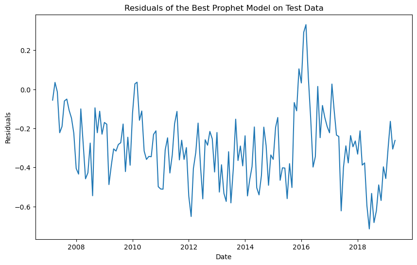

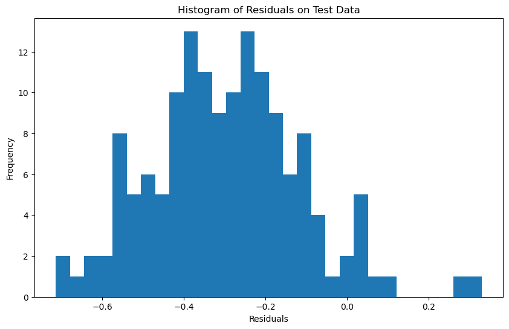

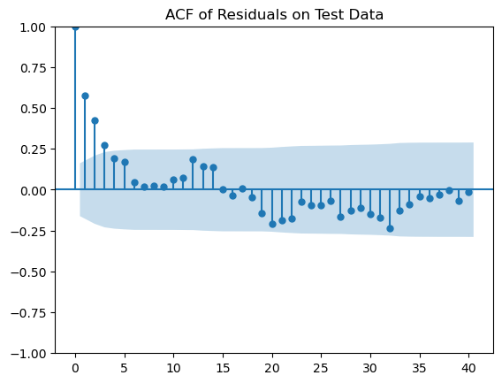

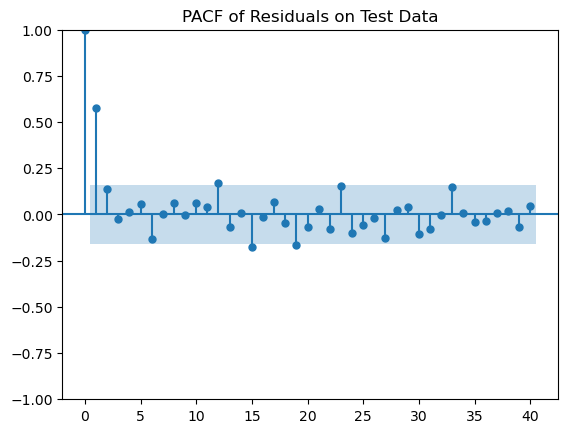

```
      lb_stat     lb_pvalue
10  99.887556  5.739523e-17
```

```python
import pandas as pd
import numpy as np
from prophet import Prophet
from sklearn.metrics import mean_absolute_error, mean_squared_error
import matplotlib.pyplot as plt
import seaborn as sns
from statsmodels.graphics.tsaplots import plot_acf, plot_pacf
from statsmodels.stats.diagnostic import acorr_ljungbox

# Prepare the data for Prophet
train['ds'] = train.index
train['y'] = train['Temperature']
test['ds'] = test.index
test['y'] = test['Temperature']

# Adjusting seasonality, changepoints prior using hyperparameter tuning
model_prophet = Prophet(
    yearly_seasonality=False,
    weekly_seasonality=False,
    daily_seasonality=False,
    seasonality_mode='additive',
    changepoint_prior_scale=1,
    n_changepoints=40
)
model_prophet.add_regressor('CO2')
model_prophet.fit(train[['ds', 'y', 'CO2']])



# Calculating residuals for the final model
final_train_residuals = train['y'] - final_train_forecast['yhat']
final_test_residuals = test['y'] - final_test_forecast['yhat']

# Performance metrics for the training set
final_mae_train = mean_absolute_error(train['y'], final_train_forecast['yhat'])
final_mse_train = mean_squared_error(train['y'], final_train_forecast['yhat'])
final_mape_train = np.mean(np.abs((train['y'] - final_train_forecast['yhat']) / train['y'])) * 100
final_smape_train = 100 / len(train) * np.sum(2 * np.abs(final_train_forecast['yhat'] - train['y']) / (np.abs(train['y']) + np.abs(final_train_forecast['yhat'])))

# Calculating MASE for the training set
naive_forecast_errors_train = train['y'].diff().dropna()
mae_naive_train = np.mean(np.abs(naive_forecast_errors_train))
final_mase_train = final_mae_train / mae_naive_train

# Performance metrics for the test set
final_mae_test = mean_absolute_error(test['y'], final_test_forecast['yhat'])
final_mse_test = mean_squared_error(test['y'], final_test_forecast['yhat'])
final_mape_test = np.mean(np.abs((test['y'] - final_test_forecast['yhat']) / test['y'])) * 100
final_smape_test = 100 / len(test) * np.sum(2 * np.abs(final_test_forecast['yhat'] - test['y']) / (np.abs(test['y']) + np.abs(final_test_forecast['yhat'])))

# Calculating MASE for the test set
naive_forecast_errors_test = test['y'].diff().dropna()
mae_naive_test = np.mean(np.abs(naive_forecast_errors_test))
final_mase_test = final_mae_test / mae_naive_test

print(f'Final Training MAE: {final_mae_train}')
print(f'Final Training MSE: {final_mse_train}')
print(f'Final Training MAPE: {final_mape_train}')
print(f'Final Training sMAPE: {final_smape_train}')
print(f'Final Training MASE: {final_mase_train}')

print(f'Final Test MAE: {final_mae_test}')
print(f'Final Test MSE: {final_mse_test}')
print(f'Final Test MAPE: {final_mape_test}')
print(f'Final Test sMAPE: {final_smape_test}')
print(f'Final Test MASE: {final_mase_test}')

# Plotting the residuals for the test set
plt.figure(figsize=(10, 6))
plt.plot(test.index, final_test_residuals)
plt.title('Residuals of the Best Prophet Model on Test Data')
plt.xlabel('Date')
plt.ylabel('Residuals')
plt.show()

# Histogram of residuals for the test set
plt.figure(figsize=(10, 6))
plt.hist(final_test_residuals, bins=30)
plt.title('Histogram of Residuals on Test Data')
plt.xlabel('Residuals')
plt.ylabel('Frequency')
plt.show()

# Plotting ACF of residuals
plt.figure(figsize=(10, 6))
plot_acf(final_test_residuals, lags=40)
plt.title('ACF of Residuals on Test Data')
plt.show()

# Plotting PACF of residuals
plt.figure(figsize=(10, 6))
plot_pacf(final_test_residuals, lags=40)
plt.title('PACF of Residuals on Test Data')
plt.show()

# Performing Ljung-Box test on residuals
lb_test_results_final = acorr_ljungbox(final_test_residuals, lags=[10], return_df=True)
print(lb_test_results_final)
```

C.10 pts Using your best prophet model, include co2 as an external regressor. Predict the test set. Include the following: MAE, MSE, MAPE, sMAPE, MASE. Can use prebuilt functions or calculate by hand.

```
20:32:38 - cmdstanpy - INFO - Chain [1] start processing
20:32:38 - cmdstanpy - INFO - Chain [1] done processing
```

```
MAE with CO2 Regressor: 0.15293734718437682
MSE with CO2 Regressor: 0.03722781830397879
MAPE with CO2 Regressor: 0.26334874212520987
sMAPE with CO2 Regressor: 0.2631110861383507
MASE with CO2 Regressor: 1.1758216265886785
```

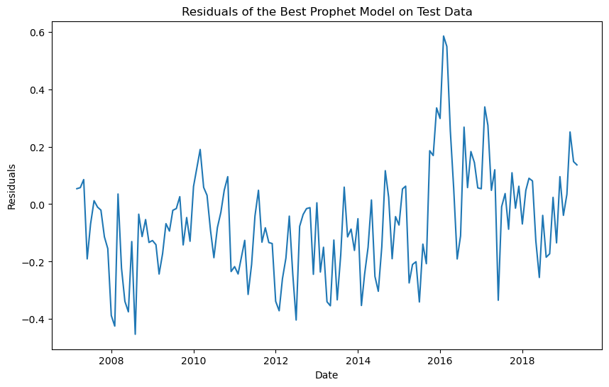

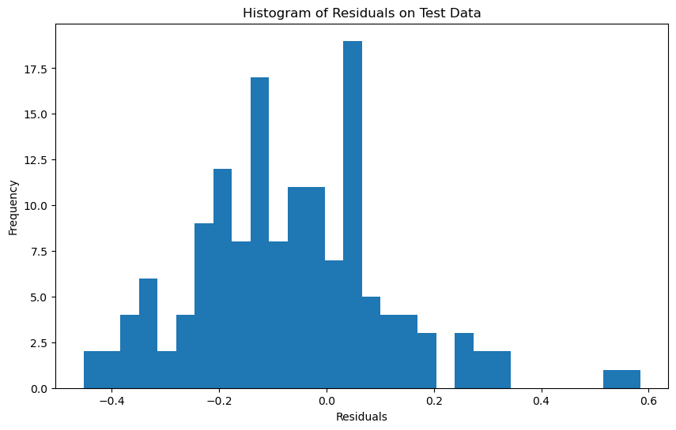

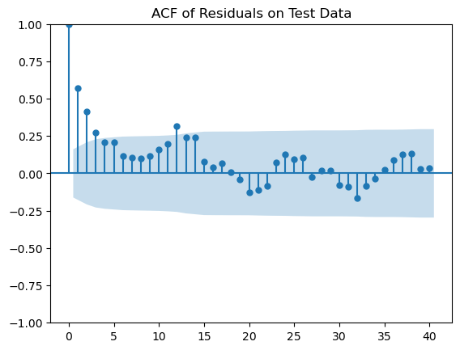

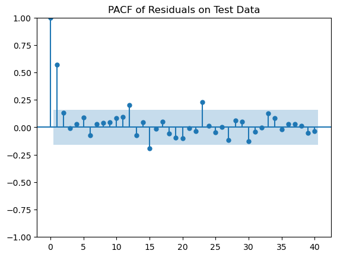

```
       lb_stat     lb_pvalue
10  111.468619  2.697100e-19
```

```python
import pandas as pd
import numpy as np
from prophet import Prophet
from sklearn.metrics import mean_absolute_error, mean_squared_error
import matplotlib.pyplot as plt
import seaborn as sns
from statsmodels.graphics.tsaplots import plot_acf, plot_pacf
from statsmodels.stats.diagnostic import acorr_ljungbox


# Fiting the best Prophet model with CO2 as an external regressor
model = Prophet(
    yearly_seasonality=False,
    n_changepoints=40,
    changepoint_prior_scale=1
)

# Adding CO2 as an external regressor
model.add_regressor('CO2')

# Fitting the model
model.fit(train[['ds', 'y', 'CO2']])

# Creating a dataframe for future predictions including the test period
future_data = pd.concat([train, test], axis=0)
future_data.reset_index(drop=True, inplace=True)

# Making predictions
forecast_data = model.predict(future_data[['ds', 'CO2']])

# Aligning forecast data with test data
forecast_data.set_index('ds', inplace=True)
forecast_data = forecast_data.loc[test['ds']]

# Calculating residuals
residuals = test['y'] - forecast_data['yhat']

# Performance metrics
mae = mean_absolute_error(test['y'], forecast_data['yhat'])
mse = mean_squared_error(test['y'], forecast_data['yhat'])
mape = np.mean(np.abs((test['y'] - forecast_data['yhat']) / test['y'])) * 100
smape = 100 / len(test) * np.sum(2 * np.abs(forecast_data['yhat'] - test['y']) / (np.abs(test['y']) + np.abs(forecast_data['yhat'])))

# Calculating MASE
naive_forecast_errors = test['y'].diff().dropna()
mae_naive = np.mean(np.abs(naive_forecast_errors))
mase = mae / mae_naive

print(f'MAE with CO2 Regressor: {mae}')
print(f'MSE with CO2 Regressor: {mse}')
print(f'MAPE with CO2 Regressor: {mape}')
print(f'sMAPE with CO2 Regressor: {smape}')
print(f'MASE with CO2 Regressor: {mase}')

# Plotting the residuals for the test set
plt.figure(figsize=(10, 6))
plt.plot(test['ds'], residuals)
plt.title('Residuals of the Best Prophet Model on Test Data')
plt.xlabel('Date')
plt.ylabel('Residuals')
plt.show()

# Histogram of residuals for the test set
plt.figure(figsize=(10, 6))
plt.hist(residuals, bins=30)
plt.title('Histogram of Residuals on Test Data')
plt.xlabel('Residuals')
plt.ylabel('Frequency')
plt.show()

# Plotting ACF of residuals
plt.figure(figsize=(10, 6))
plot_acf(residuals, lags=40)
plt.title('ACF of Residuals on Test Data')
plt.show()

# Plotting PACF of residuals
plt.figure(figsize=(10, 6))
plot_pacf(residuals, lags=40)
plt.title('PACF of Residuals on Test Data')
plt.show()

# Performing Ljung-Box test on residuals
lb_test_results_final = acorr_ljungbox(residuals, lags=[10], return_df=True)
print(lb_test_results_final)
```

D.5 pts Give a summary of your modeling in prophet. What improved the model, what made the fit worse. Give your reasonings why this would happen given the patterns in the data.

Part 4. 10 pts – conclusion

5 pts Which was the best model according to your error metrics? 5 pts If you had this data for 100 locations (different pairs of time series), how would you approach modeling this data?

5 pts If you had this data for 100 locations (different pairs of time series), how would you approach modeling this data?

When dealing with temperature, time, and CO2 data for 100 different locations, the approach requires more robust data management and individualized modeling strategies. Each location might exhibit unique patterns, trends, and seasonality, necessitating separate models or approaches for each. Initially, I would preprocess the data to ensure consistency, handle missing values, and normalize the datasets. Then, I would perform exploratory data analysis (EDA) for each location to understand local patterns, followed by creating lagged features, derived metrics, and interaction terms. Utilizing Prophet models with CO2 as an external regressor, I would train models for each location, employing parallel processing and automated hyperparameter tuning. Regular monitoring, automated retraining, and leveraging regional similarities through hierarchical models or transfer learning would ensure accurate and scalable predictions across all locations.

The END!!